# SolisenseImport

Natasha Ryan

Maximilian Berthold

Douglas A. Campbell

2023-03-29

*Some of the code used to create this R Notebook was refurbished from “PlateAbImport.Rmd” written by Maximilian Berthold, Douglas A. Campbell, Melissa L. Rioux, Sarah J Gore, and Alyson MacCormack.*

# To Do

FFT analysis of FvFm vs Flashnumber  
Data - Raw Data - NoDecay - Fit - files from 20230314  
Small dataset: 32 flashes at each of 0.5, 1, 2, 4, and 8 second intervals done at 10 and 18°C

Issue: to generate poster references, bib file had to be in poster folder  
Add references somehow? “..” path?

Add secondary y-axis for flash spacing

Choose (ask Campbell)  
- Facet by time or temperature  
maybe choose to illustrate whichever shows a more significant difference (seems to be spacing)  
- Graph/analyze Fm or FvFm  
which is better

```r
library(tidyverse)
library(lubridate)
library(zoo)
```

# Set Project Variables

```r
Project <- "LOW"
DataOut <- file.path("..","Data", "CleanData")
CalibData <- file.path("..","Data", "CalibData")

#Temporary RunDate during auditing
#RunDate <- "Refit"

#DataIn <- file.path("..","Data", "RawData","Fit", fsep = .Platform$file.sep)
DataIn <- file.path("..","Data", "RawData","NoDecay","Fit", fsep = .Platform$file.sep)

FileID <- "fit"

FileEncode <- "UTF-8"
#guess_encoding says 'ASCII"

Delimiter <- ","

HeaderRows <- 0
```

```r
us_s = 1000000
photons_umol = 6.022E17
A2_m2 = 1E20
```

```r
#ActPARCal <- readRDS("~/Dropbox/CampbellLabProtocols/ChlorophyllFluorescence/SolisenseInformation/SolisenseInformation_DCCalibParam.Rds")

ActPARCrossCal <- list.files(path = CalibData, full.names = TRUE) %>%
     map_df(~readRDS(file  = .))

#intercept set to 0 in lm in SolisenseInformation.Rproj/SolisenseCalibCompare.Rmd
ActPARCrossCal <- ActPARCrossCal |>
  rename(#Intercept = `estimate_(Intercept)`,
         Slope = `estimate_LIFT_Gen_Developer.cal`,
         #Intercept_SE = `std.error_(Intercept)`,
         Slope_SE = `std.error_LIFT_Gen_Developer.cal`)
```

```r
Wavelengths_nm = c(445, 470, 505, 535, 590)
Colours_nm = c("darkblue", "dodgerblue", "darkgreen", "yellowgreen",  "darkorange")


names(Colours_nm) <- Wavelengths_nm
Colours_nm
```

```
##           445           470           505           535           590
##    "darkblue"  "dodgerblue"   "darkgreen" "yellowgreen"  "darkorange"
```

```r
SolisenseFiles <- list.files(path = DataIn, pattern = FileID, full.names = TRUE)
SolisenseFiles
```

```
##  [1] "../Data/RawData/NoDecay/Fit/20230309_NaOm1293_10C_05S_fit.csv"
##  [2] "../Data/RawData/NoDecay/Fit/20230309_NaOm1293_10C_1S_fit.csv"
##  [3] "../Data/RawData/NoDecay/Fit/20230309_NaOm1293_10C_2S_fit.csv"
##  [4] "../Data/RawData/NoDecay/Fit/20230309_NaOm1293_10C_4S_fit.csv"
##  [5] "../Data/RawData/NoDecay/Fit/20230309_NaOm1293_10C_8S_fit.csv"
##  [6] "../Data/RawData/NoDecay/Fit/20230314_NaOm1305_10C_05S_fit.csv"
##  [7] "../Data/RawData/NoDecay/Fit/20230314_NaOm1305_10C_1S_fit.csv"
##  [8] "../Data/RawData/NoDecay/Fit/20230314_NaOm1305_10C_2S_fit.csv"
##  [9] "../Data/RawData/NoDecay/Fit/20230314_NaOm1305_10C_4S_fit.csv"
## [10] "../Data/RawData/NoDecay/Fit/20230314_NaOm1305_10C_8S_fit.csv"
## [11] "../Data/RawData/NoDecay/Fit/20230314_NaOm1305_18C_05S_fit.csv"
## [12] "../Data/RawData/NoDecay/Fit/20230314_NaOm1305_18C_1S_fit.csv"
## [13] "../Data/RawData/NoDecay/Fit/20230314_NaOm1305_18C_2S_fit.csv"
## [14] "../Data/RawData/NoDecay/Fit/20230314_NaOm1305_18C_4S_fit.csv"
## [15] "../Data/RawData/NoDecay/Fit/20230314_NaOm1305_18C_8S_fit.csv"
```

```r
#test for duplicate file names
unique(duplicated(SolisenseFiles))
```

```
## [1] FALSE
```

# Create Data Frame

purrr::map to read all files

```r
SolFits <- SolisenseFiles %>%
  map_df(~read.delim_plus(flnm =., file_encode = FileEncode, delimiter = Delimiter, header_rows = HeaderRows))
```

```r
#for NoDecayDataset
SolFitsTrim <- SolFits %>%
  filter(!grepl("----", DATE)) %>% # remove rows with "----"
  select(-c("RFID_User_Data", "Barcode_Data","PIF", "Lon", "Lat", "GPS_stat","X")) %>% # remove superfluous columns
  mutate(Filename = str_remove(string = Filename, pattern = "_fit.csv")) %>%
  mutate(Filename = str_remove(string = Filename, pattern = "../Data/RawData/NoDecay/Fit/")) %>%
  separate(Filename, into=c("YYYYMMDD", "CultureID", "Temp_C", "PulseSpace_s"), sep = "([\\/\\_])", remove = FALSE) %>%
  mutate(YYYYMMDD = lubridate::ymd(YYYYMMDD),
          TIME = as.character(TIME)) %>%
   rename(ObsDate = DATE,
         ObsTime = TIME,
         FvFm = "Fv.Fm") %>%
  mutate(FvFm = as.numeric(as.character(FvFm)),
         nm445 = as.numeric(as.character(Light_1)),
         nm470 = as.numeric(as.character(Light_2)),
         nm505 = as.numeric(as.character(Light_3)),
         nm535 = as.numeric(as.character(Light_4)),
         nm590 = as.numeric(as.character(Light_5)),
         IR = as.numeric(as.character(Light_6))) %>%
  mutate(ObsDateTime = lubridate::ymd_hms(paste(ObsDate, ObsTime))) %>%
  relocate(ObsDateTime, .after = ObsTime) %>%
  relocate(CultureID, .before = ObsDate)

SolFitsTrim2 <-SolFitsTrim[-(1:160),] %>%
  group_by(Filename) %>%
  mutate(Flashnumber = row_number()) %>%
  relocate(Flashnumber, .before=p) %>%
  mutate(Etime_s = (as.numeric(Time__mSec) - min(as.numeric(Time__mSec), na.rm = TRUE))/1000, .before=Flashnumber) %>%
  ungroup()
```

```r
#only use this chunk if analyzing data from Data-RawData-WithDecay-Fit
#create new data frame, had to remove extra column
#SolFits2 <- SolFits[-32]
#assign correct names
#Fixnames <- colnames(SolFits)[22:32]
#rename columns
#colnames(SolFits2)[21:31] <- c(Fixnames)
```

```r
# for WithDecay Fit Dataset

#Think of better ways to do this
#Careful about RunDate, which is the label of a RunDate sub-folder.
#SolFitsTrim <- SolFits %>%
  #filter(!grepl("----", DATE)) %>% # remove rows with "----"
 # select(-c("RFID_User_Data", "Barcode_Data","PIF", "Lon", "Lat", "GPS_stat","X")) %>% # remove superfluous columns
  #mutate(Filename = str_remove(string = Filename, pattern = "_fit.csv")) %>%
  #mutate(Filename = str_remove(string = Filename, pattern = "../Data/RawData/NoDecay/Fit/")) %>%
  #separate(Filename, into=c("YYYYMMDD", "CultureID", "Temp_C", "PulseSpace_s"), sep = "([\\/\\_])", remove = FALSE) %>%
  #separate(Filename, into = c("Project", "YYYYMMDD", "CultureID","Temp_C", "PulseSpace_s","Ex_WL", "Flashpower"), sep = "([\\/\\_])", remove = FALSE) %>%
 # mutate(YYYYMMDD = lubridate::ymd(YYYYMMDD),
         # TIME = as.character(TIME)) %>% #time-column may be read in as factor, and as.character changes it to numeric; using lubdridate::hms would only change the format to 13H 4M 2S but does not work later to merge into one DateTime-column
  #rename(ObsDate = DATE,
        # ObsTime = TIME,
       #  FvFm = "Fv.Fm") %>%
 # mutate(Ex_WL = as.factor(as.numeric(Ex_WL))) %>%
  #mutate(FvFm = as.numeric(as.character(FvFm)),
        # nm445 = as.numeric(as.character(Light_1)),
        # nm470 = as.numeric(as.character(Light_2)),
        # nm505 = as.numeric(as.character(Light_3)),
       # nm535 = as.numeric(as.character(Light_4)),
       #  nm590 = as.numeric(as.character(Light_5)),
        # IR = as.numeric(as.character(Light_6))) %>%
 # mutate(ObsDateTime = lubridate::ymd_hms(paste(ObsDate, ObsTime))) %>%
 # relocate(ObsDateTime, .after = ObsTime) %>%
 # relocate(CultureID, .before = ObsDate)

#SolFitsTrim2 <-SolFitsTrim %>%
#  group_by(Filename) %>%
 # mutate(Flashnumber = row_number()) %>%
 # relocate(Flashnumber, .before=p) %>%
  #mutate(Etime_s = (as.numeric(Time__mSec) - min(as.numeric(Time__mSec), na.rm = TRUE))/1000, .before=Flashnumber) %>%
  #ungroup()
```

# Basic plots

Fm vs Flashnumber line; facet by temp

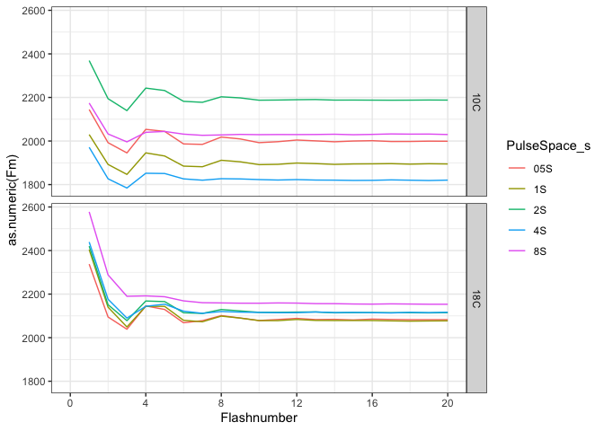

```r
#facetbytemp
SolFitsTrim2 %>%
  ggplot()+
  geom_line(aes(x=Flashnumber, y=as.numeric(Fm), group=PulseSpace_s, colour=PulseSpace_s))+
  scale_x_continuous(limits=c(0,20), breaks=seq(0,20,4)) +
  facet_grid("Temp_C") +
  theme_bw()
```

Fm vs Flashnumber line; facet by flash spacing

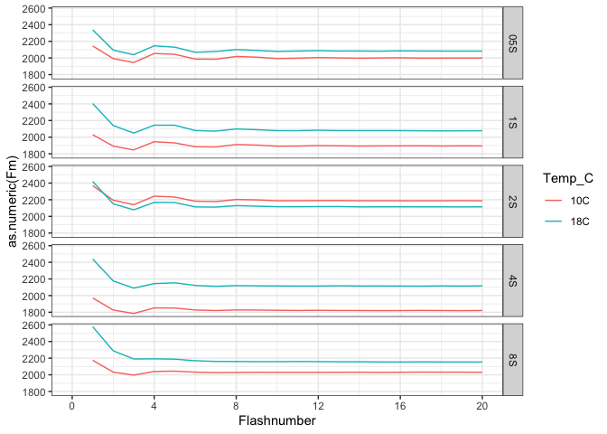

```r
#facetbyspacing
SolFitsTrim2 %>%
  ggplot()+
  geom_line(aes(x=Flashnumber, y=as.numeric(Fm), group=Temp_C, colour=Temp_C)) +
  scale_x_continuous(limits=c(0,20), breaks=seq(0,20,4)) +
  facet_grid("PulseSpace_s") +
  theme_bw()
```

**Very rough** results:  
At **10c**  
Flash spacing- Very approximate # of flashes 0.5s-18  
1s-14  
1s-14  
4s-12  
8s-8

At 10c, maintains periodicity longest at 0.5, followed by 1&2, then 4, and finally 8 damps out fastest  
-as expected

Maximum fluorescence is more variable  
-why?

At **18c**,  
Flash spacing- Very approximate # of flashes  
0.5s-16  
1s-12  
1s-10  
4s-8  
8s-8

At 18c, same pattern in flash duration but overall shorter

(line kinda shows it better than point, ask campbell?)

Biggest gap between 10&18c is at 4s  
-why?

**One to use** (according to Campbell):  
FvFm vs Flashnumber point

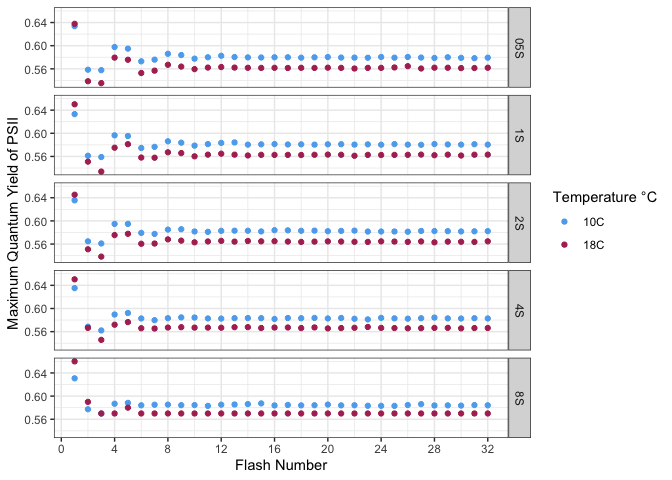

```r
SolFitsTrim2 %>%
  ggplot()+
  geom_point(aes(x=Flashnumber, y=as.numeric(FvFm), group=Temp_C, colour=Temp_C)) +
  facet_grid("PulseSpace_s") +
  scale_x_continuous(breaks=seq(0,32,4)) +
  #scale_x_continuous(limits=c(0,12), breaks=seq(0,12,4)) +
  scale_colour_manual(values = c("steelblue2","maroon")) +
  theme(legend.position = "right") + xlab("Flash Number") + ylab("Maximum Quantum Yield of PSII") +
  labs(colour="Temperature °C") +
  theme_bw()
```

FvFm vs Time point

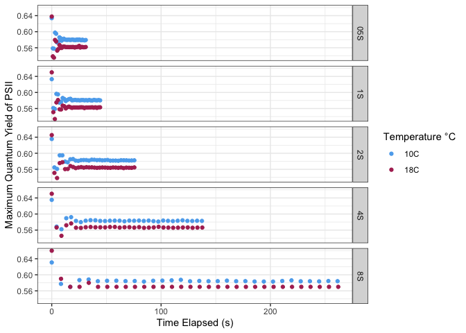

```r
SolFitsTrim2 %>%
  ggplot()+
  geom_point(aes(x=Etime_s, y=as.numeric(FvFm), group=Temp_C, colour=Temp_C)) +
  facet_grid("PulseSpace_s") +
  scale_colour_manual(values = c("steelblue2","maroon")) +
  theme(legend.position = "right") + xlab("Time Elapsed (s)") + ylab("Maximum Quantum Yield of PSII") +
  labs(colour="Temperature °C") +
  theme_bw()
```

FvFm vs Flashnumber as line; facet by spacing

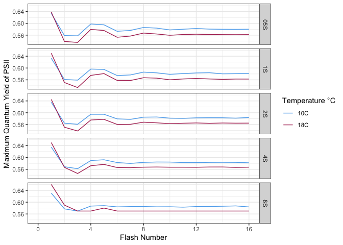

```r
#facet by spacing
SolFitsTrim2 %>%
  ggplot()+
  geom_line(aes(x=Flashnumber, y=as.numeric(FvFm), group=Temp_C, colour=Temp_C)) +
  facet_grid("PulseSpace_s") +
  #scale_x_continuous(breaks=seq(0,32,4)) +
  scale_x_continuous(limits=c(0,16), breaks=seq(0,16,4)) +
  scale_colour_manual(values = c("steelblue2","maroon")) +
  theme(legend.position = "right") + xlab("Flash Number") + ylab("Maximum Quantum Yield of PSII") +
  labs(colour="Temperature °C") +
  theme_bw()
```

FvFm vs Flashnumber as line; facet by temp

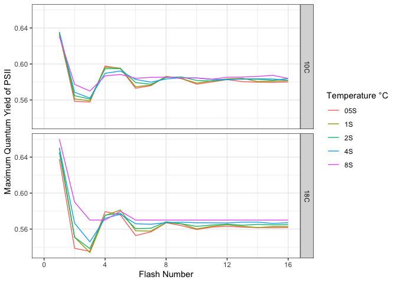

```r
# facet by temp
SolFitsTrim2 %>%
  ggplot()+
  geom_line(aes(x=Flashnumber, y=as.numeric(FvFm), group=PulseSpace_s, colour=PulseSpace_s)) +
  facet_grid("Temp_C") +
  #scale_x_continuous(breaks=seq(0,32,4)) +
  scale_x_continuous(limits=c(0,16), breaks=seq(0,16,4)) +
  #scale_colour_manual(values = c("steelblue2","maroon")) +
  theme(legend.position = "right") + xlab("Flash Number") + ylab("Maximum Quantum Yield of PSII") +
  labs(colour="Temperature °C") +
  theme_bw()
```

Within each temp, periodicity is weaker with inc pulse spacing

Fm shows better periodicity than FvFm??  
-maybe use that instead?  
But FvFm is closer between temps

FvFm vs Flashnumber (by t) is kind of easier to read (ask Campbell)

Try Fo:

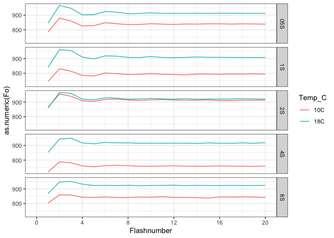

```r
SolFitsTrim2 %>%
  ggplot()+
  geom_line(aes(x=Flashnumber, y=as.numeric(Fo), group=Temp_C, colour=Temp_C)) +
  scale_x_continuous(limits=c(0,20), breaks=seq(0,20,4)) +
  facet_grid("PulseSpace_s") +
  theme_bw()
```

Fo = No.

```r
saveRDS(SolFitsTrim2, file.path(DataOut, paste(Project, "SolFitsTrim2.Rds", sep = "_"), fsep = .Platform$file.sep))
```

# Bibliography

—————————— Other code from template———————————

Add ActPARcorr with proper correction factors for TC and no TC Intercepts for cross conversions set to 0. Some smarter way to do this with map etc….

start chunk{r ActPARcorr} SolFitsTrim <- SolFitsTrim |> mutate(nm445Corr = case_when(TempCont == “TC” ~ nm445 * ActPARCrossCal$Slope[ActPARCrossCal$DCLamp == “Pwr1_uE” & ActPARCrossCal$Models == "DCWaterJacketlm_tidy"], TempCont == "noTC" ~ nm445 * ActPARCrossCal$Slope[ActPARCrossCal$DCLamp == "Pwr1_uE" & ActPARCrossCal$Models == “DCCuvettelm_tidy”]), nm470Corr = case_when(TempCont == “TC” ~ nm470 * ActPARCrossCal$Slope[ActPARCrossCal$DCLamp == “Pwr2_uE” & ActPARCrossCal$Models == "DCWaterJacketlm_tidy"], TempCont == "noTC" ~ nm470 * ActPARCrossCal$Slope[ActPARCrossCal$DCLamp == "Pwr2_uE" & ActPARCrossCal$Models == “DCCuvettelm_tidy”]), nm505Corr = case_when(TempCont == “TC” ~ nm505 * ActPARCrossCal$Slope[ActPARCrossCal$DCLamp == “Pwr3_uE” & ActPARCrossCal$Models == "DCWaterJacketlm_tidy"], TempCont == "noTC" ~ nm505 * ActPARCrossCal$Slope[ActPARCrossCal$DCLamp == "Pwr3_uE" & ActPARCrossCal$Models == “DCCuvettelm_tidy”]), nm535Corr = case_when(TempCont == “TC” ~ nm535 * ActPARCrossCal$Slope[ActPARCrossCal$DCLamp == “Pwr4_uE” & ActPARCrossCal$Models == "DCWaterJacketlm_tidy"], TempCont == "noTC" ~ nm535 * ActPARCrossCal$Slope[ActPARCrossCal$DCLamp == "Pwr4_uE" & ActPARCrossCal$Models == “DCCuvettelm_tidy”]), nm590Corr = case_when(TempCont == “TC” ~ nm590 * ActPARCrossCal$Slope[ActPARCrossCal$DCLamp == “Pwr5_uE” & ActPARCrossCal$Models == "DCWaterJacketlm_tidy"], TempCont == "noTC" ~ nm590 * ActPARCrossCal$Slope[ActPARCrossCal$DCLamp == "Pwr5_uE" & ActPARCrossCal$Models == “DCCuvettelm_tidy”]), IRCorr = case_when(TempCont == “TC” ~ IR * ActPARCrossCal$Slope[ActPARCrossCal$DCLamp == “PwrIR_uE” & ActPARCrossCal$Models == "DCWaterJacketlm_tidy"], TempCont == "noTC" ~ IR * ActPARCrossCal$Slope[ActPARCrossCal$DCLamp == "PwrIR_uE" & ActPARCrossCal$Models == “DCCuvettelm_tidy”]))

SolFitsTrim <- SolFitsTrim %>% mutate(across(.cols = c(Light_1:ETR), .fns = as.numeric)) %>% mutate(ActPAR = nm445 + nm470 + nm505 + nm535 + nm590 + IR) |> mutate(ActPARCorr = nm445Corr + nm470Corr + nm505Corr + nm535Corr + nm590Corr + IRCorr)#better ways to do this?

SolFitsTrim[1,]

#generate column with duration of light step in s #add a column adding Dark1s based upon any step < 5 s #replace NA for first dark with nominal 181; issue will be changing durations of light steps across each run SolFitsTrim <- SolFitsTrim %>% group_by(Source.DataFile, CultureID, Ex_WL) %>% #mutate(Step_s = as.numeric(ObsDateTime - lag(ObsDateTime)), .after = ObsDateTime) %>% mutate(Step_s = replace_na(as.numeric(ObsDateTime - lag(ObsDateTime)), 181), .after = ObsDateTime) %>% mutate(LR_s = as.numeric(ObsDateTime - ObsDateTime[1]), .after = Step_s) %>% mutate(Dark1s = if_else(Step_s > 5, 0, 1), .after = Step_s) %>% relocate(Ex_WL, .after = Dark1s) %>% relocate(ActPAR, .after = Ex_WL) #Figure out how to cope with final step at 0 PAR, not followed by Dark1s step #separate Dark1s rows #Figure out how to re-match Dark1s to appropriate light steps

end chunk {r ActPARcorr}

start chunk {r prelimplots} SolFitsTrim %>% filter(Dark1s == 0) %>% filter(Tau2QA < 20000) %>% ggplot() + geom_point(aes(x = ActPARCorr, y = Tau2QA, colour = as.factor(TempCont), size = LR_s)) + #scale_colour_manual(values = Colours_nm) + facet_grid(cols = vars(Ex_WL), rows = vars(CultureID)) + theme_bw()

SolFitsTrim %>% #filter(Dark1s != 0) %>% ggplot() + geom_point(aes(x = ActPARCorr, y = Alp2QA, colour = as.factor(TempCont), size = LR_s)) + #scale_colour_manual(values = Colours_nm) + facet_grid(cols = vars(Ex_WL), rows = vars(CultureID)) + theme_bw()

end chunk {r prelimplots}

Oxborough & Baker 1997 for Fo’

start chunk {r estimate parameters} SolFitsTrim2 <- SolFitsTrim %>% group_by(Source.DataFile, CultureID, Ex_WL, TempCont) %>% mutate(Fodark = Fo[1], Fmdark = Fm[1], Sigdark = Sig[1], TauAv = ((Tau1QA * Alp1QA) + (Tau2QA * Alp2QA))/(Alp1QA + Alp2QA), aLHIIdark = (Fmdark * Fodark)/(Fmdark - Fodark), Fomin = min(Fo, na.rm = TRUE), Fmmax = max(Fm, na.rm = TRUE), FoOxbo = Fomin/(((Fmmax - Fomin)/Fmmax) + (Fomin/Fm)), Sigmax = max(Sig, na.rm = TRUE), #aLHIIminmax = (Fmmax * Fomin)/(Fmmax - Fomin), aLHIIOxbomax = (Fmmax * FoOxbo)/(Fmmax - FoOxbo), Sig_m2psii = Sig/A2_m2, ActPARCorr_photonsm2s = ActPARCorr * photons_umol, #Ctau1 = 1/(1 + (Sig_m2psii * ActPARCorr_photonsm2s * (Tau1QA/us_s))), #Ctau2 = 1/(1 + (Sig_m2psii * ActPARCorr_photonsm2s * (Tau2QA/us_s))), Ctauav = 1/(1 + (Sig_m2psii * ActPARCorr_photonsm2s * (TauAv/us_s))), #qp = (Fm - Fo)/(Fm - lead(Fo)), #(Fm’ - Fs)/(Fm’ - Fo’); messes up every 2nd row from double tap data but then filter out rows from ‘dark’ qpOxbo = (Fm - Fo)/(Fm - FoOxbo), #JVPSII_aLHIIminmax = ActPARCorr_photonsm2s * aLHIIminmax * FvFm, #issue with FvFm in cyanobacteria; minimized with blue light excitation #JVPSII_aLHIIdark = ActPARCorr_photonsm2s * aLHIIdark * FvFm, JVPSII_aLHIIOxbomax = ActPARCorr_photonsm2s * aLHIIOxbomax * FvFm, #ETRCtau1 = Sig_m2psii * Ctau1 * ActPARCorr_photonsm2s, #ETRCtau2 = Sig_m2psii * Ctau2 * ActPARCorr_photonsm2s, ETRCtauav = Sig_m2psii * Ctauav * ActPARCorr_photonsm2s, #ETRqp = Sig_m2psii * qp * ActPARCorr_photonsm2s, ETRqpOxbo = Sig_m2psii * qpOxbo * ActPARCorr_photonsm2s, #ETRGorbo = (1/TauAv[7])*((ActPARCorr*FvFm)/(ActPARCorr[7]*FvFm[7]))* us_s, TestTauAvSat = 1/TauAv[ActPARCorr_photonsm2s == max(ActPARCorr_photonsm2s)], ETRGorbo = (1/TauAv[ActPARCorr_photonsm2s == max(ActPARCorr_photonsm2s)])*((ActPARCorr_photonsm2s*FvFm)/(max(ActPARCorr_photonsm2s))*(FvFm[ActPARCorr_photonsm2s == max(ActPARCorr_photonsm2s)]))* us_s, #Pmax x scaling for change in yield and light *(#)*relies upon phiPSII which is not absolute in cyanos JVPSII_ETRtauav_FoSig = ETRCtauav * Fomin/Sigmax, #Sigmax not converted A2_m2 JVPSII_ETRqpOxbo_FoSig = ETRqpOxbo * Fomin/Sigmax, JVPSII_ETRtauav_aLHII_Sig = ETRCtauav * aLHIIOxbomax/Sigmax, JVPSII_ETRqpOxbo_aLHII_Sig = ETRqpOxbo * aLHIIOxbomax/Sigmax) %>% ungroup()

end chunk {r estimate parameters}

start chunk {r prelimplots2} SolFitsTrim2 %>% filter(Dark1s == 0) %>% ggplot() + geom_point(aes(x = ActPARCorr, y = aLHIIOxbomax, colour = as.factor(TempCont))) + #geom_point(aes(x = ActPARCorr, y = aLHIIminmax), shape = “cross”) + #scale_colour_manual(values = Colours_nm) + facet_grid(cols = vars(Ex_WL), rows = vars(CultureID)) + theme_bw()

SolFitsTrim2 %>% filter(Dark1s == 0) %>% ggplot() + geom_point(aes(x = ActPARCorr, y = ETRqpOxbo, colour = as.factor(TempCont))) + geom_point(aes(x = ActPARCorr, y = ETRGorbo), shape = “cross”) + #scale_colour_manual(values = Colours_nm) + facet_grid(cols = vars(Ex_WL), rows = vars(CultureID)) + theme_bw()

SolFitsTrim %>% filter(Dark1s == 0) %>% ggplot() + geom_point(aes(x = Ctau1, y = qp, colour = as.factor(TempCont))) + #geom_point(aes(x = ActPARCorr, y = aLHIIminmax), shape = “cross”) + #scale_colour_manual(values = Colours_nm) + facet_grid(cols = vars(Ex_WL), rows = vars(CultureID)) + geom_abline(intercept = 0, slope = 1, linetype = “dashed”) + coord_fixed(xlim = c(0,1), ylim = c(0,1), ratio = 1) + theme_bw()

SolFitsTrim2 %>% filter(Dark1s == 0) %>% ggplot() + geom_point(aes(x = Ctauav, y = qpOxbo, colour = as.factor(TempCont))) + #geom_point(aes(x = ActPARCorr, y = aLHIIminmax), shape = “cross”) + #scale_colour_manual(values = Colours_nm) + facet_grid(cols = vars(Ex_WL), rows = vars(CultureID)) + geom_abline(intercept = 0, slope = 1, linetype = “dashed”) + coord_fixed(xlim = c(0,1), ylim = c(0,1), ratio = 1) + theme_bw()

SolFitsTrim2 %>% filter(Dark1s == 0) %>% ggplot() + geom_point(aes(x = ActPARCorr, y = JVPSII_ETRtauav_FoSig, colour = as.factor(TempCont))) + #geom_point(aes(x = ActPARCorr, y = aLHIIminmax), shape = “cross”) + #scale_colour_manual(values = Colours_nm) + facet_grid(cols = vars(Ex_WL), rows = vars(CultureID)) + theme_bw()

SolFitsTrim2 %>% filter(Dark1s == 0) %>% ggplot() + geom_point(aes(x = JVPSII_ETRqpOxbo_FoSig, y = JVPSII_ETRtauav_aLHII_Sig, colour = as.factor(TempCont))) + #geom_point(aes(x = ActPARCorr, y = aLHIIminmax), shape = “cross”) + #scale_colour_manual(values = Colours_nm) + geom_abline(intercept = 0, slope = 1, linetype = “dashed”) + coord_fixed(ratio = 1) + facet_grid(cols = vars(Ex_WL), rows = vars(CultureID)) + theme_bw()

SolFitsTrim2 %>% filter(Dark1s == 0) %>% ggplot() + geom_point(aes(x = JVPSII_ETRqpOxbo_FoSig, y = JVPSII_aLHIIOxbomax, colour = as.factor(TempCont))) + #geom_point(aes(x = ActPARCorr, y = aLHIIminmax), shape = “cross”) + #scale_colour_manual(values = Colours_nm) + geom_abline(intercept = 0, slope = 1, linetype = “dashed”) + #coord_fixed(ratio = 1) + facet_grid(cols = vars(Ex_WL), rows = vars(CultureID)) + theme_bw()

#ETRGorbo works well for blue light but appears to fail for 590 nm; possible issue with low FV/FM with PBsome excitation?

SolFitsTrim2 %>% #filter(Dark1s == 0) %>% ggplot() + geom_point(aes(x = ETRCtauav, y = ETRGorbo, colour = as.factor(TempCont))) + #geom_point(aes(x = ActPARCorr, y = aLHIIminmax), shape = “cross”) + #scale_colour_manual(values = Colours_nm) + geom_abline(intercept = 0, slope = 1, linetype = “dashed”) + #coord_fixed(ratio = 1) + facet_grid(cols = vars(Ex_WL), rows = vars(CultureID)) + theme_bw()

end chunk {r prelimplots2}